# gambling_model

Cher

4/15/2021

# Load Model Data

Description of two models:

Two simple models are implemented in ACT-R, performing the gambling task depending on two distinctive mechanisms.

### Model1: Declarative Model (version 2.0)

The model randomly evaluates an action GUESS-MORE or GUESS-LESS, then retrieving memories about prior feedback. If “WIN” memory is retrieved, the model chooses the evaluated action. If “LOSE”/“Neutral” memory is retrieved, the model chooses the alternative action.

### Model2: RL Models.

The model makes decision relying on procedural memory, pressing “MORE”/“LESS” key. GUESS-MORE and GUESS-LESS productions are competing. In the end, a feedback is given, the model receives either +1/-1/0 reward to all previous productions, and the utility of all previous fired productions will be affected.

```r
model1.raw <- read.csv("./MODEL120210423_102311_fnca_log.csv") #%>% rename(Trial=X)
model2.raw <- read.csv("./MODEL220210423_102311_fnca_log.csv") #%>% rename(Trial=X)

#model1 <- read.csv("MODEL120210420.csv")
#model2 <- read.csv("MODEL220210420.csv")

model1.raw <- model1.raw %>%
  mutate(CurrentResponse = case_when(Response=="j" ~ 3,
                                     Response=="f" ~ 2),
         RT = as.numeric(RT),
         Epoch = as.numeric(Epoch))

model2.raw <- model2.raw %>%
  mutate(CurrentResponse = case_when(Response=="j" ~ 3,
                                     Response=="f" ~ 2),
         RT = as.numeric(RT),
         Epoch = as.numeric(Epoch))

# only
model1 <- model1.raw %>% filter(ans==.1 & bll==.1 & lf==.1)
model2 <- model2.raw %>% filter(alpha==.1 & egs==.1 & r==.1)
```

# Compute win-stay probabilities

```r
future_moves <- function(responses) {
  c(responses[2:length(responses)], NA)
}
past_moves <- function(responses) {
  c(NA, responses[1:length(responses)-1])
}

count_responses <- function(model.dat) {
  model.dat <- model.dat %>%
   mutate(FutureResponse = future_moves(CurrentResponse),
         PastResponse = past_moves(CurrentResponse),
         PreviousFeedback = past_moves(TrialType),
         ResponseSwitch = if_else(CurrentResponse == FutureResponse, 0, 1))
  return(model.dat)
}

# NA for all first trial in each block
clean_previous_future <- function(model.dat) {
  model.dat <- model.dat %>%
    mutate(PastResponse=ifelse(BlockTrial==0, NA, PastResponse),
           PreviousFeedback=ifelse(BlockTrial==0, NA, PreviousFeedback),
           FutureResponse=ifelse(BlockTrial==7, NA, FutureResponse),
           ResponseSwitch=ifelse(BlockTrial==7, NA, ResponseSwitch),
           )
  return(model.dat)
}

#model1.count <- clean_previous_future(count_responses(model1))
```

```r
aggregate.CurrentTrial <- function(model.dat) {
  model.aggregate <- model.dat %>%
  filter(!is.na(ResponseSwitch) & !is.na(CurrentResponse)) %>%
  group_by(Epoch, BlockType, TrialType) %>%
  dplyr::summarise(PSwitch = mean(ResponseSwitch), RT = mean(RT))
  return (model.aggregate)
}

aggregate.PreviousTrial <- function(model.dat) {
  model.aggregate <- model.dat %>%
  filter(!is.na(ResponseSwitch) & !is.na(PreviousFeedback) & !is.na(CurrentResponse)) %>%
  group_by(Epoch, BlockType, PreviousFeedback) %>%
  dplyr::summarise(PSwitch = mean(ResponseSwitch), RT = mean(RT))
  return (model.aggregate)
}

#model1.aggregate <- aggregate.CurrentTrial(model1.count)
#model1.aggregate
```

```r
PSwitch.aggplot <- function(aggregate.dat, subjID) {
  # res <- ggplot(aggregate.dat,
  #      aes(x = TrialType, y = PSwitch, col = TrialType)) +
  # facet_grid( ~ BlockType) +
  # geom_point(alpha = 0.3, size=3) +
  # scale_color_brewer(palette = "Set2") +
  # stat_summary(fun.data = "mean_cl_boot", col="black") +
  # ylim(0,1) +
  # theme_pander()

  if(!is.na(subjID)) {
    res <- ggplot(aggregate.dat %>% filter(HCPID==subjID),
                  aes(x = TrialType, y = PSwitch)) +
    facet_grid( ~ BlockType) +
    geom_line(aes(group = BlockType), alpha=.5) +
    geom_point(alpha=.5, size=3, aes(col=TrialType)) +
    ylim(0,1) +
    theme_pander()

  } else {
    res <- ggplot(aggregate.dat, aes(x = TrialType, y = PSwitch, col = Epoch)) +
    facet_grid( ~ BlockType) +
    geom_line(aes(group = Epoch), alpha=.5) +
    geom_point(alpha=.5, size=3) +
    ylim(0,1) +
    guides(col=FALSE) +
    stat_summary(fun.data = "mean_cl_boot", col="black") +
    theme_pander()
  }

  return(res)
}
RT.aggplot <- function(aggregate.dat, subjID) {
  # res <- ggplot(aggregate.dat,
  #      aes(x = TrialType, y = RT, col = TrialType)) +
  # facet_grid( ~ BlockType) +
  # geom_point(position = position_jitter(width = 0.1, height = 0.05),
  #            alpha = 0.3, size=3) +
  # scale_color_brewer(palette = "Set2") +
  # stat_summary(fun.data = "mean_cl_boot", col="black") +
  # ylim(0,2) +
  # theme_pander()
  if(!is.na(subjID)) {

    # plot  human data
    res <- ggplot(aggregate.dat %>% filter(HCPID==subjID),
                  aes(x = TrialType, y = RT)) +
    facet_grid( ~ BlockType) +
    geom_line(aes(group = BlockType), alpha=.5) +
    geom_point(alpha=.5, size=3, aes(col=TrialType)) +
    ylim(0,1) +
    theme_pander()

    # plot model data
  } else {
    res <- ggplot(aggregate.dat, aes(x = TrialType, y = RT, col = Epoch)) +
    facet_grid( ~ BlockType) +
    geom_line(aes(group = Epoch), alpha=.5) +
    geom_point(alpha=.5, size=3) +
    ylim(0,1500) +
    guides(col=FALSE) +
    stat_summary(fun.data = "mean_cl_boot", col="black") +
    theme_pander()
  }
  return(res)
}
```

Let’s look at the PSwitch and RT as a function of Current TrialType

```r
model1.count <- clean_previous_future(count_responses(model1))
model2.count <- clean_previous_future(count_responses(model2))


model1.aggregate <- aggregate.CurrentTrial(model1.count)
model2.aggregate <- aggregate.CurrentTrial(model2.count)
```

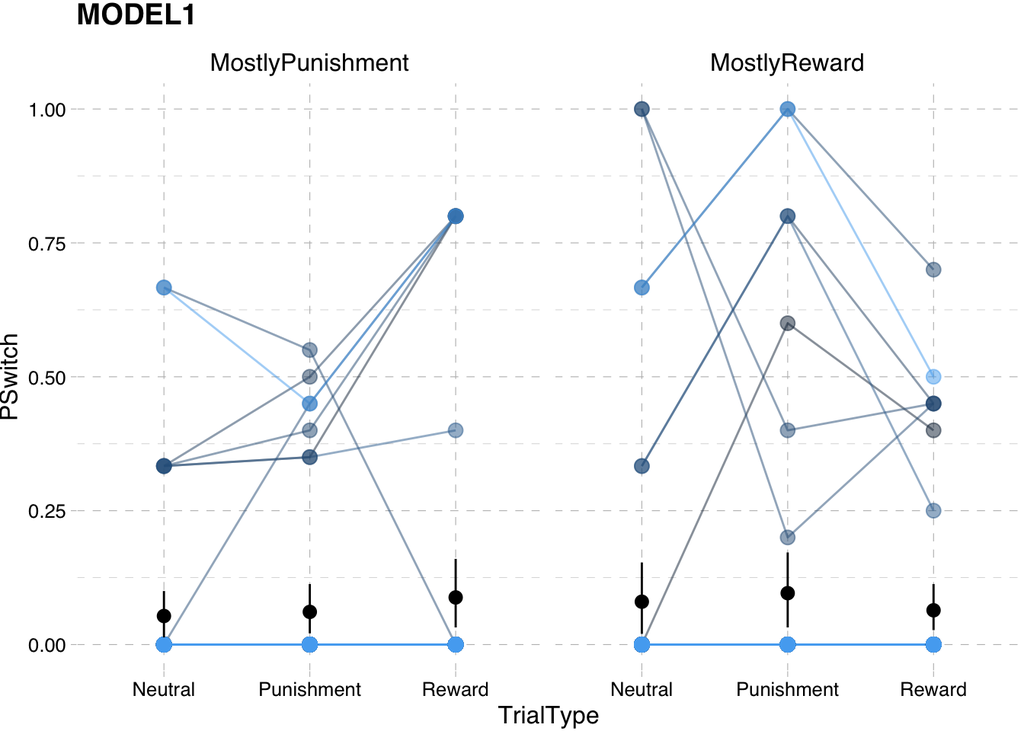

```r
PSwitch.aggplot(model1.aggregate, NA) + ggtitle("MODEL1")
```

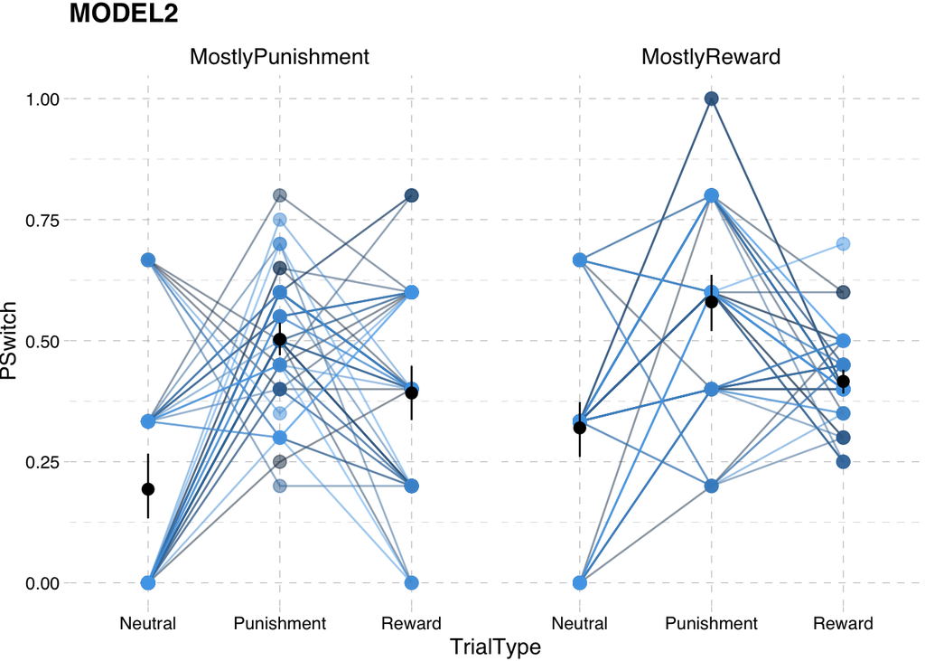

```r
PSwitch.aggplot(model2.aggregate, NA) + ggtitle("MODEL2")
```

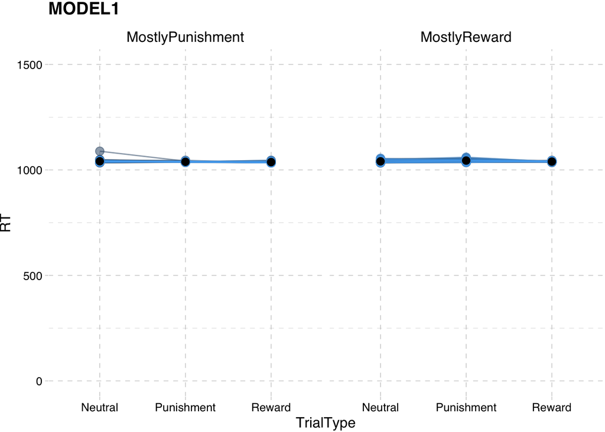

```r
RT.aggplot(model1.aggregate, NA) + ggtitle("MODEL1")
```

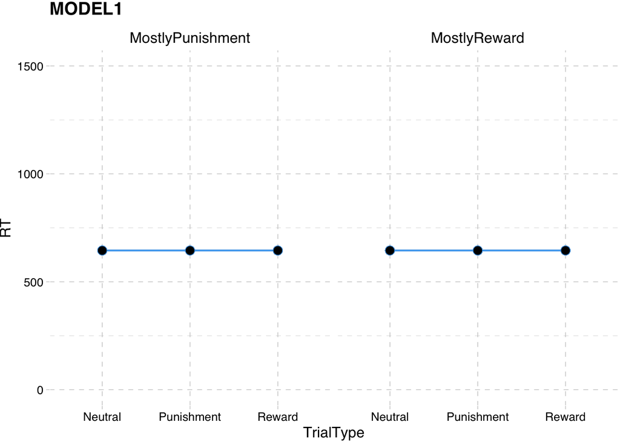

```r
RT.aggplot(model2.aggregate, NA) + ggtitle("MODEL1")
```

### Summary of Pswitch vs. CurrentTrial

Model1:

Model2:

### Summary of RT vs. CurrentTrial

Model1:

Model2:

```r
model1.pf_aggregate <- aggregate.PreviousTrial(model1.count)
model2.pf_aggregate <- aggregate.PreviousTrial(model2.count)
```

```r
PSwitch.pfaggplot <- function(aggregate.dat, subjID) {
  # res <- ggplot(aggregate.dat,
  #      aes(x = PreviousFeedback, y = PSwitch, col = PreviousFeedback,
  #          group = PreviousFeedback)) +
  # facet_grid( ~ BlockType, labeller = label_both) +
  # geom_point(alpha = 0.3, size=3) +
  # scale_color_brewer(palette = "Set2") +
  # stat_summary(fun.data = "mean_cl_boot", col="black") +
  # ylim(0,1) +
  # theme_pander()

  # plot subject
  if(!is.na(subjID)) {
    res <- ggplot(aggregate.dat %>% filter(HCPID==subjID),
                  aes(x = PreviousFeedback, y = PSwitch)) +
    facet_grid( ~ BlockType) +
    geom_line(aes(group = BlockType), alpha=.5) +
    geom_point(alpha=.5, size=3, aes(col=PreviousFeedback)) +
    ylim(0,1) +
    theme_pander()

    # plot model
  } else {
    res <- aggregate.dat %>%
    ggplot(aes(x = PreviousFeedback, y = PSwitch, col  = Epoch)) +
    facet_grid( ~ BlockType, labeller = label_both) +
    geom_line(aes(group = Epoch), alpha=.5) +
    geom_point(alpha=.5, size=3) +
    ylim(0,1) +
    guides(col=FALSE) +
    stat_summary(fun.data = "mean_cl_boot", col="black") +
    theme_pander()
  }

  return(res)
}

RT.pfaggplot <- function(aggregate.dat, subjID) {
  # res <- ggplot(aggregate.dat,
  #      aes(x = PreviousFeedback, y = RT, col = PreviousFeedback)) +
  # facet_grid( ~ BlockType, labeller = label_both) +
  # geom_point(alpha = 0.3, size=3) +
  # scale_color_brewer(palette = "Set2") +
  # ylim(0,1) +
  # stat_summary(fun.data = "mean_cl_boot", col="black") +
  # theme_pander()

  # plot subject
  if(!is.na(subjID)) {
    res <- ggplot(aggregate.dat %>% filter(HCPID==subjID),
                  aes(x = PreviousFeedback, y = RT)) +
    facet_grid( ~ BlockType) +
    geom_line(aes(group = BlockType), alpha=.5) +
    geom_point(alpha=.5, size=3, aes(col=PreviousFeedback)) +
    ylim(0,1) +
    theme_pander()

    # plot model
  } else {
    res <- aggregate.dat %>%
    ggplot(aes(x = PreviousFeedback, y = RT, col  = Epoch)) +
    facet_grid( ~ BlockType, labeller = label_both) +
    geom_line(aes(group = Epoch), alpha=.5) +
    geom_point(alpha=.5, size=3) +
    ylim(0,1500) +
    guides(col=FALSE) +
    stat_summary(fun.data = "mean_cl_boot", col="black") +
    theme_pander()
  }
  return(res)
}
```

Let’s visualize it

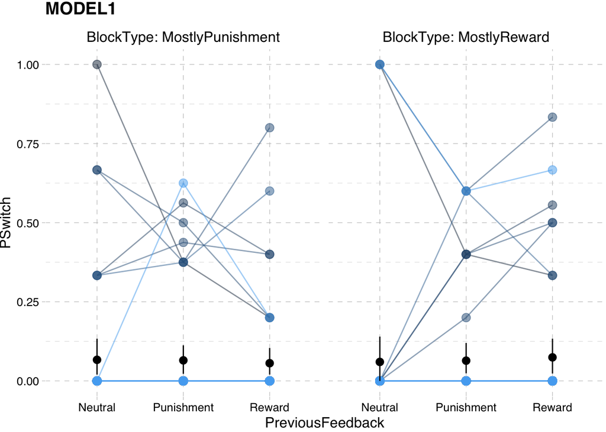

```r
PSwitch.pfaggplot(model1.pf_aggregate, NA) + ggtitle("MODEL1")
```

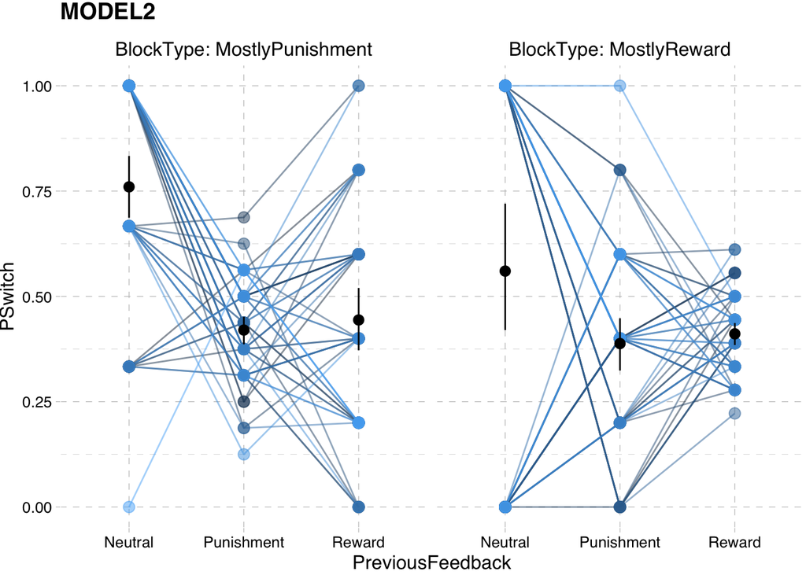

```r
PSwitch.pfaggplot(model2.pf_aggregate, NA) + ggtitle("MODEL2")
```

```r
aov(PSwitch ~ BlockType * PreviousFeedback, model2.pf_aggregate  %>% filter(PreviousFeedback!="Neutral"))  %>%
  anova_summary() %>%
  xtable() %>%
  kable(digits=4) %>%
  kable_styling(bootstrap_options = c("striped", "hover"))

aov(RT ~ BlockType * PreviousFeedback, model2.pf_aggregate  %>% filter(PreviousFeedback!="Neutral"))  %>%
  anova_summary() %>%
  xtable() %>%
  kable(digits=4) %>%
  kable_styling(bootstrap_options = c("striped", "hover"))
```

### Summary of Pswicth vs. PreviousTrial

Model1:

Model2:

### Summary of RT vs. PreviousTrial

Model1:

Model2:

```r
blockId <- sort(rep(1:4, 8))

gambling <- gambling %>%
  group_by(HCPID, RunNumber) %>%
  mutate(BlockId = blockId,
         Response = if_else(is.na(QuestionMark.RESP), 0, QuestionMark.RESP))

bg <- gambling %>%
  group_by(BlockId, HCPID, RunNumber) %>%
  summarise(BlockType = paste("Mostly", Mode(TrialType)))

gambling <- inner_join(gambling, bg)

past_moves <- function(responses) {
  c(NA, responses[1:length(responses)-1])
}

gambling <- gambling %>%
  group_by(RunNumber, BlockId) %>%
  mutate(CurrentResponse = Response,
         FutureResponse = future_moves(Response),
         PastResponse = past_moves(Response),
         PreviousFeedback = past_moves(TrialType),
         RT = QuestionMark.RT/1200) %>%
  filter(FutureResponse != 0) %>%
  #filter(CurrentResponse != 0) %>%
  mutate(ResponseSwitch = if_else(CurrentResponse == FutureResponse, 0, 1))   %>%
  select(HCPID, RunNumber, BlockId, RT, Response, PastResponse,
         CurrentResponse, FutureResponse, ResponseSwitch, BlockType, TrialType,
         PreviousFeedback, FeedbackImage)

gambling$PreviousFeedback <- as_factor(gambling$PreviousFeedback)
gambling$PreviousFeedback <- revalue(gambling$PreviousFeedback,
                                         c("1"="Reward",
                                           "2"="Punishment",
                                           "3"="Neutral"))
```

```r
subj1.aggregate <- aggregate.CurrentTrial(gambling)
subj1.pf_aggregate <- aggregate.PreviousTrial(gambling)

PSwitch.aggplot(subj1.aggregate) + ggtitle("SUBJ - 100307")
RT.aggplot(subj1.aggregate) + ggtitle("SUBJ - 100307")

PSwitch.pfaggplot(subj1.pf_aggregate) + ggtitle("SUBJ - 100307")
RT.pfaggplot(subj1.pf_aggregate) + ggtitle("SUBJ - 100307")
```

```r
gambling <- read_tsv("../../gambling_data.txt")
gambling.trials <- gambling %>%
  #filter(RunNumber==1) %>%
  select(HCPID, Trial, RunNumber, TrialType, RunTrialNumber, Block,
         QuestionMark.RESP, QuestionMark.ACC, QuestionMark.RT,
         R1MostlyReward1, R1MostlyReward2, R1MostlyPunishment1, R1MostlyPunishment3, QuestionMark.OnsetDelay,
         ConsecSameResp, ConsecLargerGuesses, ConsecSmallerGuesses, ConsecRTLess200) %>%
  rename(CurrentResponse=QuestionMark.RESP, RT=QuestionMark.RT)  %>%
  mutate(FutureResponse = future_moves(CurrentResponse),
         PastResponse = past_moves(CurrentResponse),
         ResponseSwitch = if_else(CurrentResponse == FutureResponse, 0, 1),
         PreviousFeedback = past_moves(as.character(TrialType)),
         BlockType = case_when(
           !is.na(R1MostlyReward1) ~ "MostlyReward",
           !is.na(R1MostlyReward2) ~ "MostlyReward",
           !is.na(R1MostlyPunishment1) ~ "MostlyPunishment",
           !is.na(R1MostlyPunishment3) ~ "MostlyPunishment"
         )) %>%
  select(-R1MostlyReward1, -R1MostlyReward2, -R1MostlyPunishment1, -R1MostlyPunishment3) %>%
  filter(!is.na(TrialType))

#write.csv(gambling.trials, "../../gambling_clean_data.csv")
```

```r
gambling.aggregate <- gambling.trials.session1 %>%
  filter(!is.na(ResponseSwitch) & !is.na(RT)) %>%
  group_by(HCPID, TrialType, BlockType, PreviousFeedback) %>%
  summarise(PSwitch = mean(ResponseSwitch),RT = mean(RT))

ggplot(gambling.aggregate,
       aes(x = TrialType, y = PSwitch, col = TrialType)) +
  facet_grid( ~ BlockType, labeller = label_both) +
  geom_point(position = position_jitter(width = 0.1, height = 0.05),
             alpha = 0.1) +
  scale_color_brewer(palette = "Set2") +
  stat_summary(fun.data = "mean_cl_boot", col="black") +
  theme_pander()

gambling.trials <- gambling.trials.session1 %>% select(HCPID, Trial, RunTrialNumber, TrialType, BlockType)

gambling.trials.session1 %>%
  gghistogram("RT", add = "median")
```

# Load Subject Data

```r
gambling.clean <- read_csv("../../bin/gambling_clean_data.csv") %>%
  select(-BlockType) %>% rename(BlockType=BlockTypeCoded)


gambling.cfagg <- gambling.clean %>%
  na.omit() %>%
  group_by(HCPID, BlockType, TrialType) %>%
  summarise(PSwitch = mean(ResponseSwitch), RT = mean(RT))

gambling.pfagg <- gambling.clean %>%
  na.omit() %>%
  group_by(HCPID, BlockType, PreviousFeedback) %>%
  summarise(PSwitch = mean(ResponseSwitch), RT = mean(RT))

# long format
gambling.cfagg <- left_join(gambling.cfagg %>% select(-RT) %>%
  spread(key = TrialType, value = PSwitch, sep = "."),
  gambling.cfagg %>% select(-PSwitch) %>%
  spread(key = TrialType, value = RT, sep = "."),
  by = c("HCPID", "BlockType"), suffix=c(".PSwitch",".RT"))

gambling.pfagg <- left_join(gambling.pfagg %>% select(-RT) %>%
  spread(key = PreviousFeedback, value = PSwitch, sep = "."),
  gambling.pfagg %>% select(-PSwitch) %>%
  spread(key = PreviousFeedback, value = RT, sep = "."),
  by = c("HCPID", "BlockType"), suffix=c(".PSwitch",".RT"))

#write_csv(gambling.cfagg, "../../bin/gambling_cfagg.csv")
#write_csv(gambling.pfagg, "../../bin/gambling_pfagg.csv")
```

Load clean data and select one subj data

Note: here, ResponseSwitch is 1 if: CurrentResponse != FutureResponse; is 0 if CurrentResponse==FutureResponse

```r
gambling.clean <- read_csv("../../bin/gambling_clean_data.csv") %>% mutate(BlockType=BlockTypeCoded)
subjID = "102311_fnca"

#  Pswitch as a function of current trial type and block type
gambling.cfaggregate = gambling.clean %>%
  filter(!is.na(ResponseSwitch) & !is.na(CurrentResponse)) %>%
  group_by(HCPID, BlockType, TrialType) %>%
  dplyr::summarise(PSwitch = mean(ResponseSwitch, rm.na=T), RT = mean(RT, rm.na=T))

#  Pswitch as a function of previous trial type and block type
gambling.pfaggregate = gambling.clean %>%
  filter(!is.na(ResponseSwitch) & !is.na(PreviousFeedback)) %>%
  group_by(HCPID, BlockType, PreviousFeedback) %>%
  dplyr::summarise(PSwitch = mean(ResponseSwitch, rm.na=T), RT = mean(RT, rm.na=T))
```

```r
# test whether prop is calculate correctly
gambling.cfaggregate %>% filter(HCPID==subjID)
gambling.clean %>% filter(HCPID==subjID) %>%
  filter(!is.na(ResponseSwitch)) %>%
  group_by(BlockType, TrialType , ResponseSwitch) %>%
  dplyr::summarise(n=n()) %>%
  mutate(freq = n / sum(n)) %>%
  xtable() %>% kable(digits=4) %>% kable_styling(bootstrap_options = c("striped", "hover"))

#>> yes correct
```

Visualize subject Pswitch pattern as a function of previous feedback

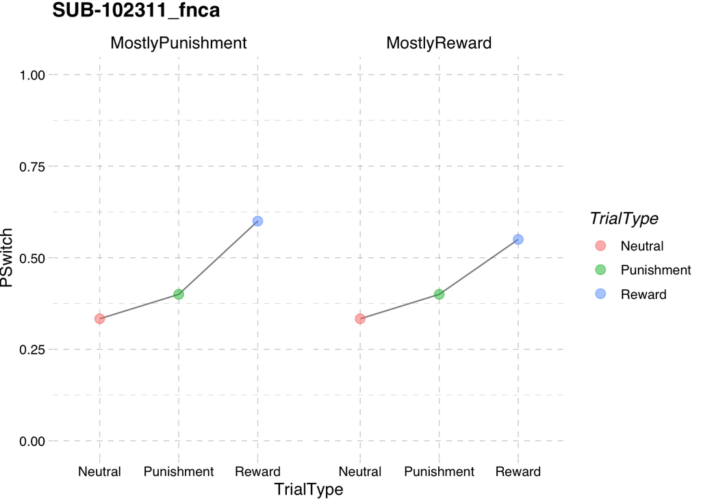

```r
PSwitch.aggplot(gambling.cfaggregate, subjID) + ggtitle(paste("SUB", subjID, sep = "-"))
```

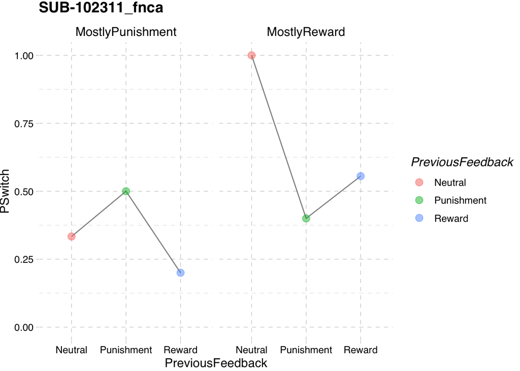

```r
PSwitch.pfaggplot(gambling.pfaggregate, subjID) + ggtitle(paste("SUB", subjID, sep = "-"))
```

# Calculate RMSE and Find Best Fit Parameter

Distribution of model1 parameters :ans, :bll, :lf

```r
dim(model1.raw)
```

```
## [1] 188800     11
```

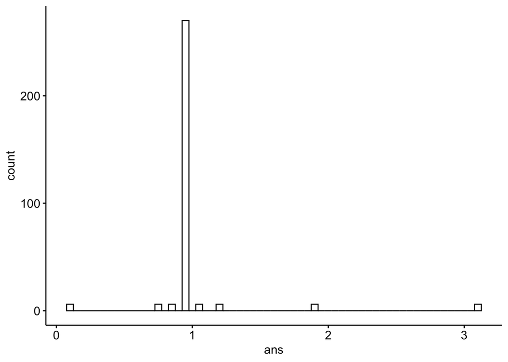

```r
model1.full.count <- clean_previous_future(count_responses(model1.raw))

model1.full.agg <- model1.full.count %>%
  filter(!is.na(ResponseSwitch) & !is.na(CurrentResponse)) %>%
  group_by(ans, bll, lf, BlockType, TrialType) %>%
  dplyr::summarise(PSwitch = mean(ResponseSwitch), RT = mean(RT))

model1.full.agg %>% gghistogram(x="ans", binwidth = .05)
```

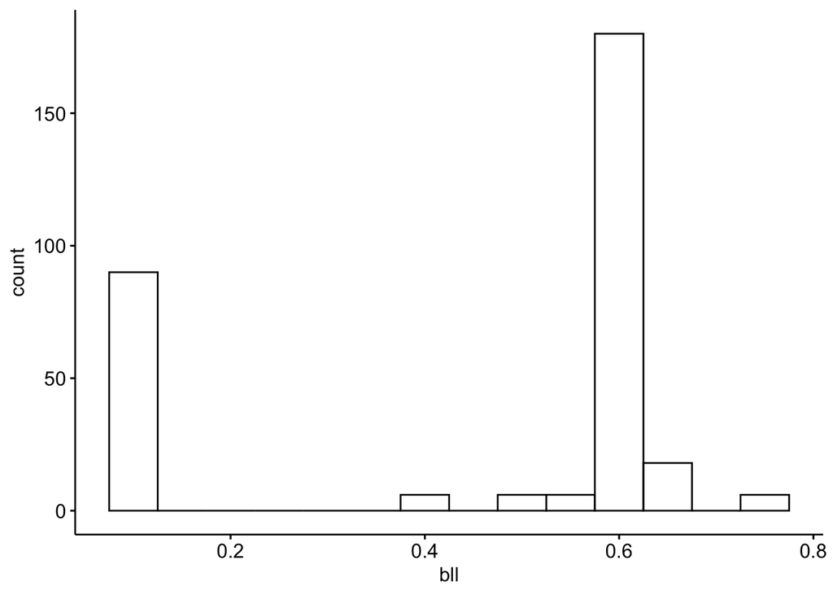

```r
model1.full.agg %>% gghistogram(x="bll", binwidth = .05)
```

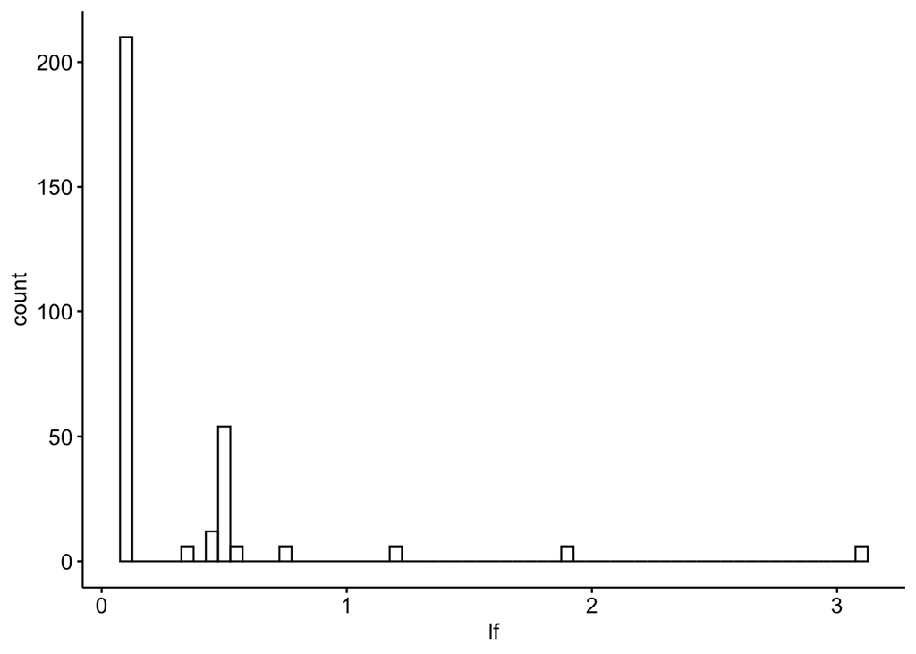

```r
model1.full.agg %>% gghistogram(x="lf", binwidth = .05)
```

Distribution model2 parameter :egs, :alpha, and :r

```r
dim(model2.raw)
```

```
## [1] 400000     11
```

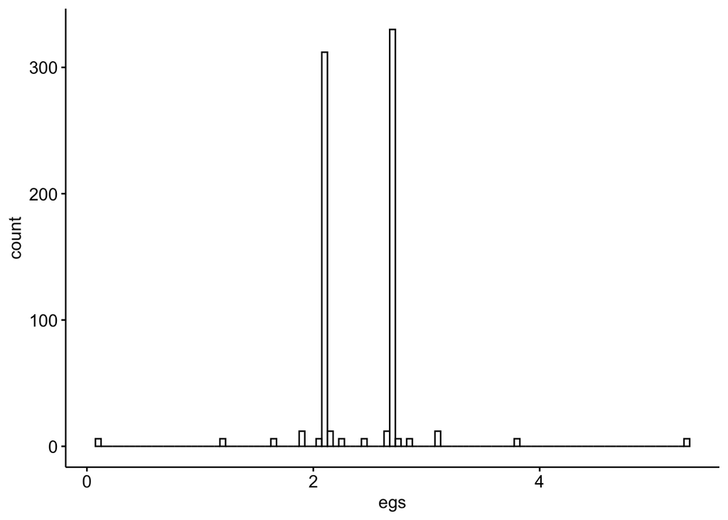

```r
model2.full.count <- clean_previous_future(count_responses(model2.raw))

model2.full.agg <- model2.full.count %>%
  filter(!is.na(ResponseSwitch) & !is.na(CurrentResponse)) %>%
  group_by(egs, alpha, r, BlockType, TrialType) %>%
  dplyr::summarise(PSwitch = mean(ResponseSwitch), RT = mean(RT))

model2.full.agg %>% gghistogram(x="egs", binwidth = .05)
```

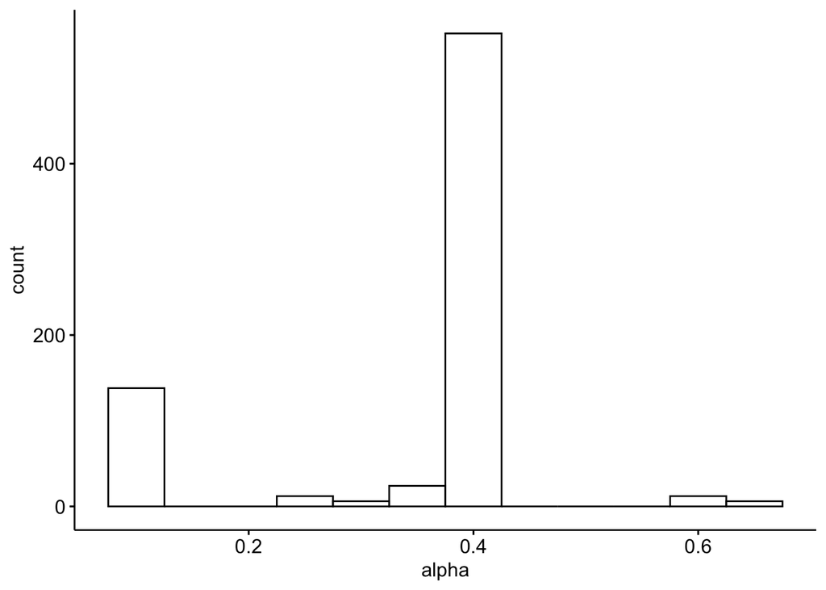

```r
model2.full.agg %>% gghistogram(x="alpha", binwidth = .05)
```

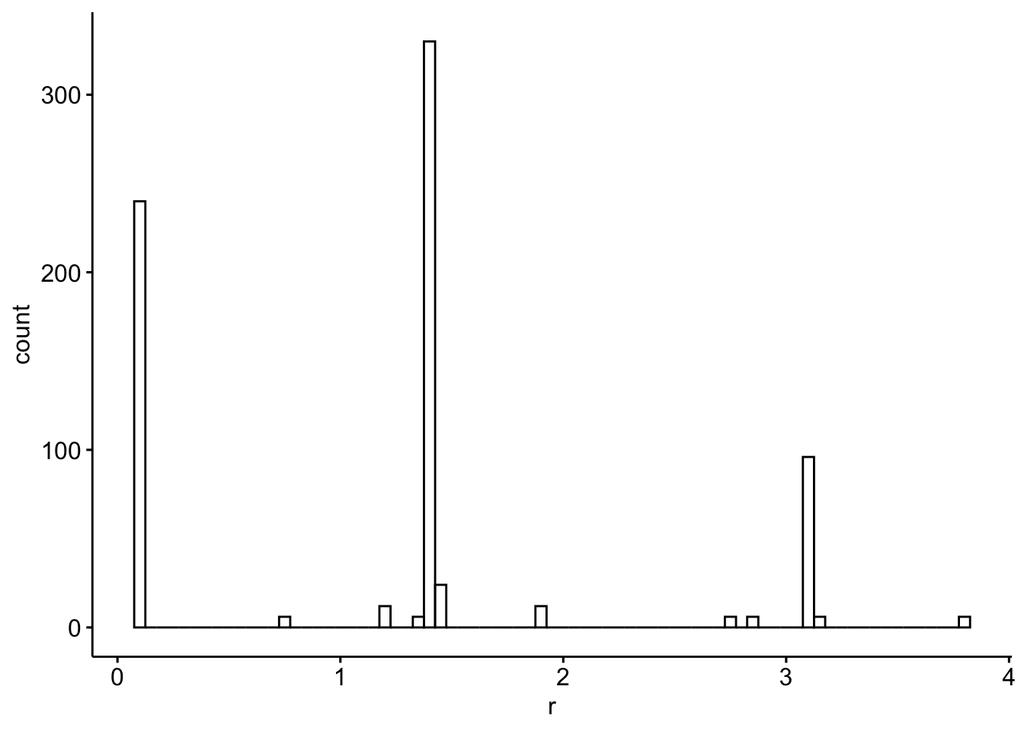

```r
model2.full.agg %>% gghistogram(x="r", binwidth = .05)
```

Next, we calalculate RMSE for each parameter combination, find the best parameter with min RMSE

```r
find_best_parameter <- function(model, model.agg, sub.agg) {
  if (model=="model1") {
    m1.param <- unique(model.agg[,c('ans','bll','lf')])
    #m1.param=m1.param[1:10,]
    m1.param$RMSE = NA
    m1.param$RMSE = as.numeric(m1.param$RMSE)

    for (i in 1:nrow(m1.param)) {
      m1.agg <- model.agg %>%
        filter(ans==m1.param[[i,'ans']] & bll==m1.param[[i,'bll']] & lf==m1.param[[i,'lf']])
        rmse_value <- rmse(m1.agg$PSwitch, sub.agg$PSwitch)
      m1.param[[i, 'RMSE']] <- rmse_value
    }
    return (m1.param)
  } else {
    m2.param <- unique(model.agg[,c('egs','alpha','r')])
    #m2.param=m2.param[1:10,]
    m2.param$RMSE = NA
    m2.param$RMSE = as.numeric(m2.param$RMSE)

    for (i in 1:nrow(m2.param)) {
      m2.agg <- model.agg %>%
        filter(egs==m2.param[[i,'egs']] & alpha==m2.param[[i,'alpha']] & r==m2.param[[i,'r']])
        rmse_value <- rmse(m2.agg$PSwitch, sub.agg$PSwitch)
      m2.param[[i, 'RMSE']] <- rmse_value
    }
    return (m2.param)
  }

}

m1.bestp <- find_best_parameter("model1", model1.full.agg, gambling.cfaggregate)
m2.bestp <- find_best_parameter("model2", model2.full.agg, gambling.cfaggregate)
m1.bestp$model = "model1"
m2.bestp$model = "model2"
```

```r
m1.bestp <- m1.bestp[order(m1.bestp$RMSE),]
m2.bestp <- m2.bestp[order(m2.bestp$RMSE),]

m1.bestp %>% head() %>% xtable() %>% kable(digits=4) %>% kable_styling(bootstrap_options = c("striped", "hover"))
```

| ans | bll | lf | RMSE | model |
| --- | --- | --- | --- | --- |
| 0.9551 | 0.6195 | 0.485 | 0.2746 | model1 |
| 0.9551 | 0.6203 | 0.100 | 0.2748 | model1 |
| 0.7295 | 0.1000 | 0.100 | 0.2750 | model1 |
| 0.9551 | 0.6393 | 0.100 | 0.2752 | model1 |
| 0.9551 | 0.5001 | 0.100 | 0.2757 | model1 |
| 0.9551 | 0.6193 | 0.100 | 0.2760 | model1 |

```r
m2.bestp %>% head() %>% xtable() %>% kable(digits=4) %>% kable_styling(bootstrap_options = c("striped", "hover"))
```

| egs | alpha | r | RMSE | model |
| --- | --- | --- | --- | --- |
| 2.1142 | 0.3781 | 1.4197 | 0.2732 | model2 |
| 2.1143 | 0.3835 | 1.4197 | 0.2733 | model2 |
| 2.1152 | 0.3835 | 1.4197 | 0.2736 | model2 |
| 2.4448 | 0.3835 | 1.4197 | 0.2737 | model2 |
| 2.1142 | 0.3835 | 1.4197 | 0.2737 | model2 |
| 2.1142 | 0.3782 | 1.4197 | 0.2738 | model2 |

```r
m1.bestp[[1,'ans']]
```

```
## [1] 0.9550822
```

By looking at min RMSE:

Best parameter chosen for model1 :ans=0.9550822 :bll=0.6194925, :lf=0.485

Best parameter chosen for model2 is :egs=2.1141706 ; alpha=0.3780524, :r=1.4196539